# Q5_Powerpoint_Present

2025-06-17

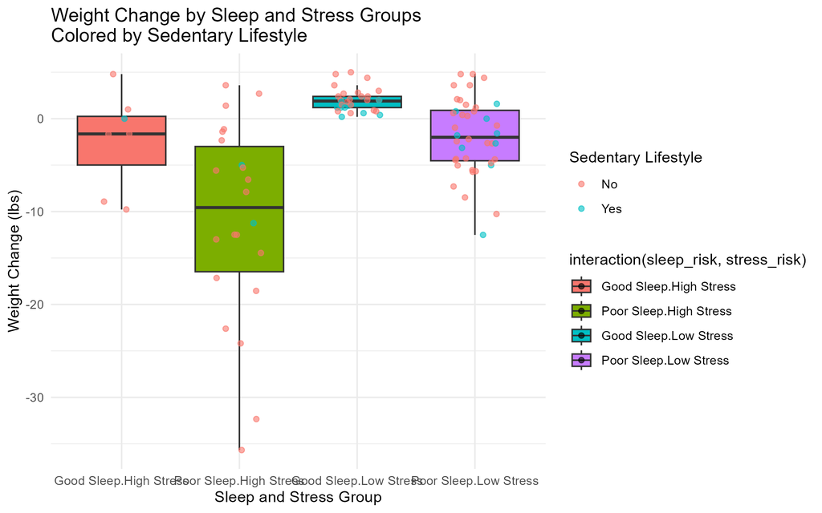

Sleep Risk by Age Group

Table: Sleep Risk vs. Age Group

| Poor Sleep Risk | age_group | Mean_Weight_Change | Count |
| --- | --- | --- | --- |
| No | Adults (20-29) | 0.2142665 | 9 |
| No | Early Career (30-39) | 1.5777778 | 9 |
| No | Middle-aged (40-49) | 2.9571429 | 7 |
| No | Preretirement (50-64) | -0.0982816 | 11 |
| No | Teenagers (<20) | 1.9500000 | 2 |
| Yes | Adults (20-29) | -3.0281494 | 15 |
| Yes | Early Career (30-39) | -7.7298256 | 14 |
| Yes | Middle-aged (40-49) | -6.2899584 | 17 |
| Yes | Preretirement (50-64) | -2.0918011 | 12 |
| Yes | Teenagers (<20) | -7.9895678 | 4 |

Stress Risk by Age Group

Table: Stress Risk vs. Age Group

| High Stress Risk | age_group | Mean_Weight_Change | Count |
| --- | --- | --- | --- |
| No | Adults (20-29) | -0.3147374 | 16 |
| No | Early Career (30-39) | 0.3380507 | 16 |
| No | Middle-aged (40-49) | -0.2082122 | 17 |
| No | Preretirement (50-64) | -0.1510524 | 16 |
| No | Teenagers (<20) | -2.1816281 | 5 |
| Yes | Adults (20-29) | -4.8072556 | 8 |
| Yes | Early Career (30-39) | -14.2037671 | 7 |
| Yes | Middle-aged (40-49) | -11.8128123 | 7 |
| Yes | Preretirement (50-64) | -3.3951248 | 7 |
| Yes | Teenagers (<20) | -17.1501307 | 1 |

```
##
## Call:
## lm(formula = `Weight Change (lbs)` ~ sleep_risk * stress_risk +
##     physical_activity + age_group + Gender + `Daily Caloric Surplus/Deficit` +
##     `BMR (Calories)` + `Duration (weeks)`, data = data)
##
## Residuals:
##      Min       1Q   Median       3Q      Max
## -21.8665  -2.2284  -0.1688   3.0284  13.3642
##
## Coefficients:
##                                             Estimate Std. Error t value Pr(>|t|)
## (Intercept)                                 1.757644   6.660167   0.264  0.79249
## sleep_riskPoor Sleep                       -7.168427   2.704340  -2.651  0.00958 **
## stress_riskLow Stress                       5.800417   2.717209   2.135  0.03566 *
## physical_activityModerately Active         -1.141517   1.892730  -0.603  0.54804
## physical_activitySedentary                 -0.539390   1.981756  -0.272  0.78615
## physical_activityVery Active               -1.075895   2.310961  -0.466  0.64272
## age_groupEarly Career (30-39)              -2.976460   1.874652  -1.588  0.11606
## age_groupMiddle-aged (40-49)               -2.225577   1.766148  -1.260  0.21107
## age_groupPreretirement (50-64)             -0.777232   1.890988  -0.411  0.68209
## age_groupTeenagers (<20)                   -3.178475   2.861000  -1.111  0.26972
## GenderM                                    -1.649830   1.596543  -1.033  0.30436
## `Daily Caloric Surplus/Deficit`             0.002322   0.002981   0.779  0.43807
## `BMR (Calories)`                           -0.001351   0.002211  -0.611  0.54296
## `Duration (weeks)`                         -0.157764   0.175486  -0.899  0.37118
## sleep_riskPoor Sleep:stress_riskLow Stress  2.979590   3.289721   0.906  0.36764
## ---
## Signif. codes:  0 ‘***’ 0.001 ‘**’ 0.01 ‘*’ 0.05 ‘.’ 0.1 ‘ ’ 1
##
## Residual standard error: 5.929 on 85 degrees of freedom
## Multiple R-squared:  0.4553, Adjusted R-squared:  0.3656
## F-statistic: 5.075 on 14 and 85 DF,  p-value: 8.498e-07
```

```
##
## Call:
## lm(formula = `Weight Change (lbs)` ~ `High Stress Risk` * age_group,
##     data = data)
##
## Residuals:
##     Min      1Q  Median      3Q     Max
## -23.865  -2.815   1.035   2.622  16.613
##
## Coefficients:
##                                                      Estimate Std. Error t value Pr(>|t|)
## (Intercept)                                           -0.3147     1.5095  -0.209  0.83531
## `High Stress Risk`Yes                                 -4.4925     2.6145  -1.718  0.08918 .
## age_groupEarly Career (30-39)                          0.6528     2.1348   0.306  0.76047
## age_groupMiddle-aged (40-49)                           0.1065     2.1031   0.051  0.95972
## age_groupPreretirement (50-64)                         0.1637     2.1348   0.077  0.93905
## age_groupTeenagers (<20)                              -1.8669     3.0936  -0.603  0.54771
## `High Stress Risk`Yes:age_groupEarly Career (30-39)  -10.0493     3.7845  -2.655  0.00937 **
## `High Stress Risk`Yes:age_groupMiddle-aged (40-49)    -7.1121     3.7668  -1.888  0.06223 .
## `High Stress Risk`Yes:age_groupPreretirement (50-64)   1.2484     3.7845   0.330  0.74226
## `High Stress Risk`Yes:age_groupTeenagers (<20)       -10.4760     7.1123  -1.473  0.14426
## ---
## Signif. codes:  0 ‘***’ 0.001 ‘**’ 0.01 ‘*’ 0.05 ‘.’ 0.1 ‘ ’ 1
##
## Residual standard error: 6.038 on 90 degrees of freedom
## Multiple R-squared:  0.4018, Adjusted R-squared:  0.342
## F-statistic: 6.718 on 9 and 90 DF,  p-value: 2.604e-07
```

## Introduction

Analysis of key determinants of health care based on WHO-funded data

Focus on sleep, stress, physical activity, and demographic differences

Goal: Provide practical insights for improving health outcomes

## Sleep as a Proxy for Health

How does high stress impact the benefits of adequate sleep?

Analysis using boxplots and regression models with interaction effects

To what extent can stress diminish or negate sleep’s positive health effects?

## Role of Physical Activity

How does physical activity influence the relationship between sleep and health?

Can physical inactivity offset the benefits of good sleep quality?

## Demographic Differences

Which age groups are most vulnerable to poor sleep, high stress, and inactivity?

How do lifestyle differences between younger and older adults affect these health determinants?

## Speaker Notes

In this presentation, I will highlight how sleep serves as a proxy for overall health, emphasizing the complex role that high stress plays in potentially reducing the positive effects of good sleep. We will also explore how physical activity modifies this relationship, examining whether inactivity can cancel out the benefits of quality sleep. Finally, I will discuss which demographic groups—particularly younger versus older adults—are most impacted by poor sleep, stress, and inactivity, providing actionable insights for targeted health interventions.